# 一不留神，僵尸就这么跳将进来了

How to cleanup the Zombie process

linux ubuntu process zombie

远程登录服务器，突然看到一个信息，你有一个僵尸进程，吓坏了😓

作者

adopapa

日期

2024/06/28,第26周

Keywords

linux ubuntu process zombie

看到系统信息中提到的僵尸进程（zombie process），尽管听起来可能有些令人担忧，但它并不一定意味着系统存在危险。不过，了解什么是僵尸进程以及如何处理它们是很重要的。

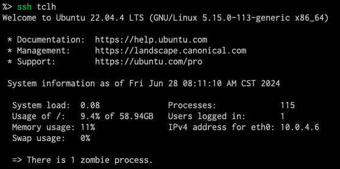

## **什么是僵尸进程？**

僵尸进程是在其执行完成后仍保留在进程表中的进程。这些进程已经终止，但其父进程还没有读取其退出状态，因此这些进程的资源尚未完全释放。它们占用的系统资源非常少，但积累太多的僵尸进程可能会耗尽系统可用的进程表条目。

## **如何查找僵尸进程？**

你可以使用 `ps` 命令来查找系统中的僵尸进程：

```
ps aux | grep Z
```

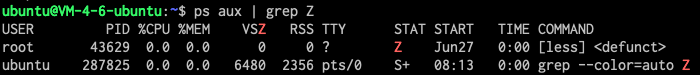

在输出中，你会看到带有 `Z` 状态码的进程，这些就是僵尸进程。

## **处理僵尸进程的方法**

### 手动即时清理

1. **手动杀掉父进程**： 找到僵尸进程的父进程ID (PPID)。你可以使用 `ps` 或 `top` 命令来查找其父进程。

   ```
   ps -o ppid= -p <zombie_pid>
   ```

   使用 `kill` 命令来结束该父进程：

   ```
   sudo kill -HUP <parent_pid>
   ```

   这会告诉父进程重新读取子进程的退出状态并释放僵尸进程。

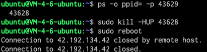

2. **重启服务或系统**： 如果僵尸进程是由某个服务引起的，重启该服务可能会解决问题。如果这个方法无效，重启系统通常会清理所有僵尸进程。

   ```
   sudo systemctl restart your_service
   # 或者
   sudo reboot
   ```

### **周期性监控和自动处理**

   对于需要持续监控并处理僵尸进程的系统，可以编写脚本定期检查并处理这些进程。
   1. **示例脚本：**

   ```
   #!/bin/bash
   zombies=$(ps aux | awk '{if ($8 ~ /Z/) print $2}')
   if [ -n "$zombies" ]; then
       for pid in $zombies; do
           parent_pid=$(ps -o ppid= -p $pid)
           [ "$parent_pid" ] && sudo kill -HUP $parent_pid
       done
   fi
   ```

   2. 设置定时任务: 将这个脚本设为定时任务，例如通过 `crontab` 设置定期运行。

   ```
   crontab -e
   # 添加以下行每小时运行一次脚本
   0 * * * * /path/to/your/script.sh
   ```

## **小结**

虽然僵尸进程本身并不会消耗大量资源，但它们积累过多可能会影响系统的稳健性。通过上面的步骤，你可以识别并处理僵尸进程，确保系统保持健康的运行状态。通常，出现一个僵尸进程并不危险，但在生产环境中应尽早处理以保持系统的清洁和高效运行。